# P1斯特鲁普效应检验

#### 自变量：文字含义与其所涂颜色的匹配关系

#### 因变量：参与者说完列表中全部文字对应颜色使用的时间。

#### H0零假设： 一致文字条件下参与者使用的时间大于或者等于不一致文字条件。

#### H1对立假设：一致文字条件下参与者使用的时间小于不一致文字条件。

#### μ0表示：一致文字条件下，说出全部文字对应颜色使用的时间总体均值。

#### μ1表示：不一致文字条件下，说出全部文字对应颜色使用时间总体均值。

#### H0：μ0 ≥ μ1

#### H1：μ0 ＜ μ1

#### α = 0.05

#### 本次实验采用双总体，相依样本检测方式，完成α= 0.05的左侧单尾t检测。

#### 关于我们采用t检验而不采用z检验的理由说明：Z检验一般适用于样本量大于30的均值差异性检验。t检验一般适用于样本量小于30的均值差异性检验，且t检验同时还要求总体符合正太分布。由于我们的数据样本量小于30，且总体符合正太分布，因此我们选择t检验作为本次检验的检验方案。

#### 关于我们采用左侧单尾检验而不采用双尾检验的理由说明：由于我们预先假设当文字与所涂颜色不匹配时会对读者的判断造成干扰从而增加思考时间导致说出文字表面所涂颜色的时间增加。预期的检测结果具有方向性，因此本实验采用左侧单尾检测。

#### 关于我们采用双总体检验而不采用单总体检验的理由说明：单总体检验是检验一个样本平均数与一个已知总体平均数的差异是否显著。双总体检验是检验两个样本平均数与其各自所代表的总体的差异是否显著。由于我们获得的数据是两个样本数据，并且需要对两个样本数据所对应的总体差异进行比较，因此我们选择双总体检验方式。

#### 关于我们采用相依样本检测方式而不采用独立样本检测方式的理由说明：

#### 根据相依样本的定义：

#### 1. （Two condition）为同一人提供两种条件，看看他们对两种条件的反映。这两种条件可以是对照组和处理组，或者两种处理类型。

#### 2. （longitudinal）纵向研究，在某个时间点测量某个值，然后在另一个时间点再次测量该变量，看看变量是否有变化。

#### 3. (Pre-test，post-test)预先测试和后期测试，测量处理前后变量的值。

#### 相依样本的优点是：可以控制个体差异，更少的受试者，成本更低，话费的时间更少。相依样本的缺点：残留效应，即第二次的测量结果会受到第一次测量结果的影响。测量的顺序也会对测量结果造成影响。

#### 根据独立样本的定义：

#### 1. （Experimental）我们可以开展实验性检验，对受试者实施处理措施.

#### 2. (Observational) 我们可以开展观察性检验，观察两组不同总体的特征然后对比。

#### 由于本次实验的类型符合相依样本定义中描述的第一种情况，属于同一受试者在两种不同的外部条件下完成测试，因此我们决定使用相依样本检测方式来完成本次检验。

#### 描述性统计值：

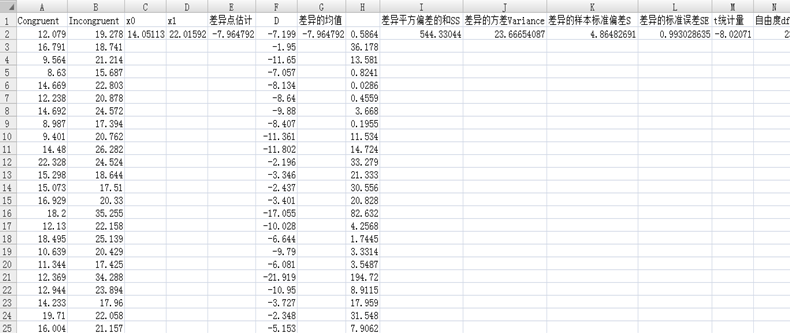

#### 样本均值x0：14.05

#### 样本均值x1：22.01

#### 差异点估计：-7.96

#### 差异的均值μ：-7.96

#### 差异的样本标准偏差S：4.86

#### 标准误差SE：0.99

#### 统计量t：-8.02

#### 自由度df：23

#### 单尾检测P值：0.00005

#### 对于α水平为0.05的左侧单尾检测来说，查表可得t的临界值是：-1.714

#### 经计算统计量t = -8.02在临界值-1.714以内，P=0.00005<0.05，因此成功拒绝零假设。

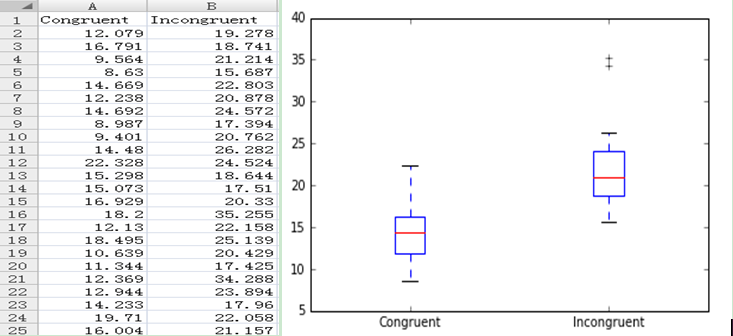

#### 通过绘制样本数据的箱线图来观察两组数据的差异可知如下信息：

#### 1. 在一致条件下，受试者的用时中位数在14左右，在不一致条件下受试者的用时中位数在21左右。并且在不一致条件下，箱线图的最小值与最大值均大于一致条件下的最小值与最大值，说明在不一致条件下，大部分的受试者都受到了干扰，导致说出文字所涂颜色的时间出现不同程度的增加。

#### 2. 在一致条件下，箱线图没有异常值，而在不一致条件下，箱线图出现了异常值，说明在不一致条件下，部分受试者在读出文字所涂颜色时出现了严重的困难导致用时极大的增加。

#### 结论：在文字颜色与文字含义不匹配时，受试者完全说完文字所涂颜色用时相比较文字颜色与文字含义匹配时有明显增加。结果与测试前的期望一致。

#### 项目所使用的资源列表以及使用说明：

#### 在一个 Stroop （斯特鲁普）任务中，参与者得到了一列文字，每个文字都用一种油墨颜色展示。参与者的任务是将文字的打印颜色大声说出来。这项任务有两个条件：一致文字条件，和不一致文字条件。在一致文字条件中，显示的文字是与它们的打印颜色匹配的颜色词，如“红色”、“蓝色”。在不一致文字条件中，显示的文字是与它们的打印颜色不匹配的颜色词，如“紫色”、“橙色”。在每个情况中，我们将计量说出同等大小的列表中的墨色名称的时间。每位参与者必须全部完成并记录每种条件下使用的时间。

#### 根据百度百科查到斯特鲁普效应（背景补充信息）：

http://baike.baidu.com/link?url=ElKXKelOvQYxZES1pMC5QWeayXg29ZEV6_Jaa3PynfFCNfr4EzklO2WGyKUWaHEB-yJ0eKTrJF0CwsJjLql_1AtYaiOsM1wCCZCaFvJD_rhw23eARttzt3FOGxNGxNvPJwHZBdvDM3dIeASlIOuSk_

#### P值查询网站：http://www.graphpad.com/quickcalcs/pValue2/

#### 箱线图的应用举例地址：http://wiki.mbalib.com/wiki/箱线图

#### 用Python画箱线图，来观察两组样本数据的差异。

#### 参考资料地址：http://blog.csdn.net/sinat_27339001/article/details/47480471